# 上級マクロ経済学II

第6回 人的資本

Author

荻巣嘉高

# 1 人的資本

## 人の「能力」

$$Y=F(K,L)$$

- $L$，$K$は物理的なヒト，モノのストック（量）を表している．
  - 生産能力は一定だと仮定している（TFPなどで一部イノベーションを反映するが）．
- ヒトの生産**能力**は一定なのか？

## 「収束」からの示唆

Mankiw et al. (1992)の議論（右図）
$$Y = K^{\alpha} H^{\beta} L^{1-\alpha - \beta}$$
として，人的資本$H$を想定．

- パネルでの比較．
  1. コノントロールなし
  2. 収束先の違いのコントロール
  3. (b)+人的資本投資をコントロール
- 条件付き収束のフィットを高めることが観測される．

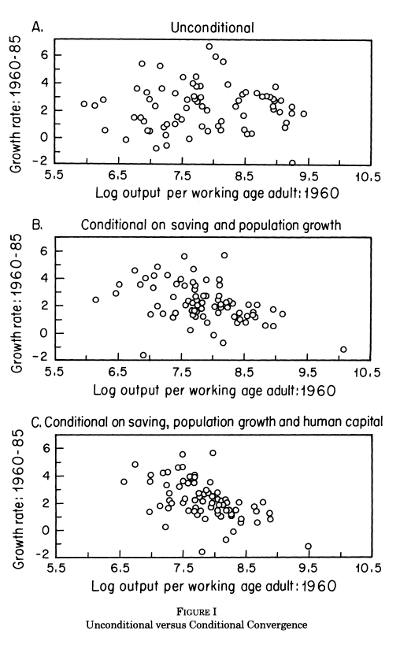

## 限界生産性からの示唆

- 一人が生産に貢献する量＝限界生産性
- 均衡では
  $$\frac{\partial Y}{\partial L} = w$$

ナイーブに考えるなら

- 大学進学がその人の生産能力を高める．
  - その結果，高い限界生産性に基づいて高い賃金をもらう．
  - Mincer (1958) からあるクラシカルな議論の一つ．

学歴を重要視する理由のひとつ．

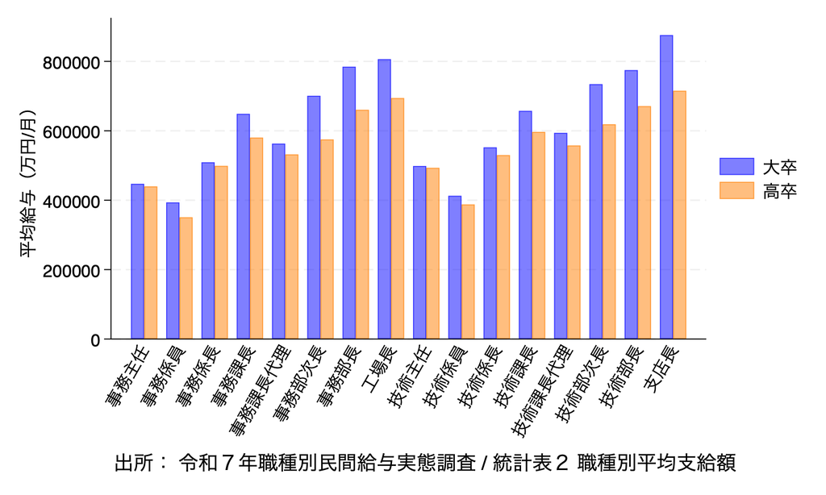

## 知の生産と蓄積

生産性に貢献するヒトの技能や能力を全てひっくるめて，**人的資本**と呼ぶ (Becker, 1962)．

- 人間は生まれた時何の知識も技能もないことは令和も江戸も同じ．
- それにも関わらず，人的資本が蓄積されるのはなぜ？

# 2 教育と人的資本蓄積

## どこで教育するか

- 小学校から大学（院）までの教育
  - 公立 vs 私立
  - 過熱教育
- 就職してからの訓練（On-the-Job-Training：OJT）
  - 企業特殊的技能 vs 一般的技能

## 学校での教育

[figure not shown]

## どこで就職するか

高卒vs 大卒の例

- 大卒の方が平均的には給料が良い．
  - 近年でも大学進学率は50〜60%程度．
  - 全員進学しないのはなぜ？

## 「ある人」に関する簡単な推論

- 大卒になる時の期待生涯所得$I^{\rm{U}}$
  - ただし，大学進学のための直接コスト$C^{\rm{D}}$が必要．
  - 進学せずに働いた場合には$C^{\rm{O}}$だけの所得が得られたはず（機会費用）．
- 高卒になる時の期待生涯所得$I^{\rm{H}}$．

$$I^{\rm{U}} - C^{\rm{D}} -C^{\rm{O}} > I^{\rm{H}}$$
なら**この人**は進学する．

- 人によってこの不等式は反転しうる．

## 問20

人間の長寿化は教育投資を高めるだろうか，低めるだろうか，あるいは無関係だろうか． 論拠を示しつつ答えよ．

## 教育投資の決定権

- 学校教育の意思決定は種々の意思決定主体が関与しうる．
  - 本人
  - 親
  - 場合によっては親戚等々

意思決定主体によって，モデルの特定化は異なる．

## 基本的なモデル

2期間家計が生存するOLGモデルで，以下のようなセットアップを考えよう．

- 人口成長なし．
- 部分均衡モデル
  - 生産セクターは不変（利子率&賃金は一定）
- 若年期
  - 所得は賃金$w$に人的資本水準$h_t$をかけた$h_t w$だけ得られる．
  - 消費&貯蓄&子供への教育投資（子供に金をかけると効用が上がる，joy-of-givingの仮定）．
- 老年期
  - 貯蓄を切り崩して消費．

## 家計

$$U_t^{\rm{\ell}} = \log c_t^{\rm{y,\ell}} + \beta \log c_{t+1}^{\rm{o,\ell}} + \gamma \log e_{t}$$
を，以下の予算制約のもとで最大化する．
$$\begin{aligned}
c_t^{\rm{y}} + p e_t + s_t &= w h_t \\
c_{t+1}^{\rm{o,\ell}} &= (1+r) s_t \\
h_{t+1} &= 1+e_t^{\phi}
\end{aligned}$$
ただし，$e_t$は教育費，$p$は教育の価格，$0< \phi < 1$．

- 最適化を解くにはラグランジュの未定乗数法を使う．

## 家計の選択

$$\begin{aligned}
c_t^{\rm{y}} &= \frac{w h_t}{1 + \beta+ \gamma} \\
c_{t+1}^{\rm{o}} &= \frac{\beta (1+r) w h_t}{1 + \beta+ \gamma} \\
e_t &= \frac{\gamma w h_t}{p(1 + \beta+ \gamma)}
\end{aligned}$$

教育量$e_t$の上昇がもたらされるのは：

- 教育の価格$p$の下落
- 所得$h_t w$の上昇
- 効用の中の，子供の質にかかるウエイト$\gamma$の上昇

## 人的資本の動態

$$h_{t+1} = 1 + \left[ \frac{\gamma w}{p(1 + \beta+ \gamma)} \right]^{\phi} h_t^{\phi}$$

- 縦軸に$h_{t+1}$，横軸に$h_t$をおいた**位相図**に描くと，動学がわかる．
  - **安定的**に定常状態$h_{t+1} = h_t = h^*$へたどりつく．
- 子供の人的資本に対するウエイトが高くなれば，将来的に高い所得の定常状態（=$w h_t$）へ辿り着く．
- $\phi \in (0,1)$が満たされないときどうなる？

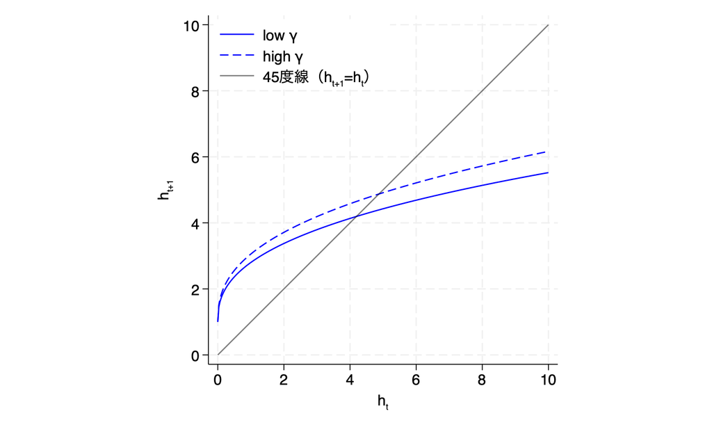

## Notes

- 子供への教育は遺産のひとつとして考えられる．
  - 世代を超えた意思決定を行うキー．
- 最初の資産$h_0$がどんな家計でも，$h^*$へ収束する．
  - 教育を通じて所得格差がなくなっていく．
  - これは現実的か？
- 教育への投資は高い所得水準を達成する．
  - 生産セクターも考える（Lucas, 1988）なら，公的教育の意義が（Glomm and Ravikumar, 1992）？

## 人的資本のスピルオーバー

- 高い人的資本が高い人的資本の再生産を促す．
  - 先生の質が高まるイメージ．
  - 人的資本がある水準$\bar{h}$を超えると，教育の質が上がるとする．

$A>1$を使って，人的資本生産関数を次のように修正する．
$$h_{t+1} = \left\{
\begin{aligned}
& 1+e_t^{\phi} & \text{if }h_t \le \bar{h} \\
& 1+A e_t^{\phi} & \text{if } h_t > \bar{h}
\end{aligned}\right.$$

すると，人的資本蓄積の位相図が2つの均衡を持ちうる．

- **貧困の罠**の出現．

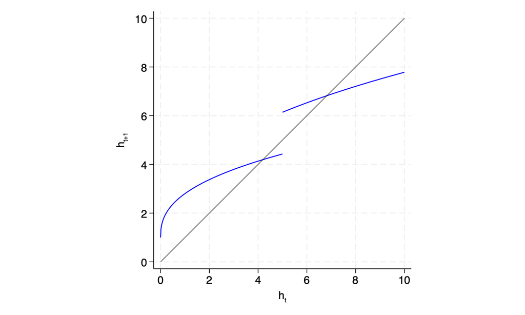

# 3 発展：最低消費がある場合

## 最低消費

生活するには，最低限の消費量が必要．

- 若年期は労働を行うため，最低限の消費量が$\underline{c}$を満たしていないと労働ができないとする．
  - 最低消費制約
- 消費量の確保のために，教育投資や将来の消費が犠牲になる可能性がある．

## 家計

若年期には，最低限消費しなければならない水準$\underline{c}>0$が存在するとする．

$$U_t^{\rm{\ell}} = \log c_t^{\rm{y,\ell}} + \gamma \log (1+e_{t})$$
を，以下の予算制約のもとで最大化する．
$$\begin{aligned}
c_t^{\rm{y}} + p e_t + s_t &= w h_t \\
h_{t+1} &= 1+e_t^{\phi} \\
c_t &\ge \underline{c}, ~ e_t \ge 0
\end{aligned}$$

- 2期目は省略（実質的にはNon-OLG）．
- $\log e_t \to \log (1+e_t)$への変更は，$e=0$を許すため．
- 最適化を解くにはKKTを使う（ここでは深く触れない）．

## 最適選択

3つのレジームが存在．2つの閾値を設定．

- $\bar{h}_0 = h_t \le \underline{c}/w$
- $\bar{h}_1 = h_t \le \underline{c} [(1 + \gamma)- p]/w$
1. $h_t < \bar{h}_0$のとき，
   $$\begin{aligned}
   c_t^{\rm{y}} &= w h_t \\
   e_t &= 0
   \end{aligned}$$
2. $\bar{h}_0 \le h_t \le \bar{h}_1$のとき，
   $$\begin{aligned}
   c_t^{\rm{y}} &= \underline{c} \\
   e_t &= \frac{w h_t - \underline{c}}{p}
   \end{aligned}$$
3. $\bar{h}_1 \le h_t$のとき，
   $$\begin{aligned}
   c_t^{\rm{y}} &= \frac{w h_t + p}{1 + \gamma} \\
   e_t &= \frac{\gamma (w h_t + p)}{p(1 + \gamma)}-1
   \end{aligned}$$

## 人的資本の蓄積

$$h_{t+1} = \left\{
\begin{aligned}
&1 ~ \text{if }h_t < \bar{h}_0 \\
&1 + \left[ \frac{w h_t - \underline{c}}{p} \right]^{\phi} ~ \text{if } \bar{h}_0 \le h_t < \bar{h}_1 \\
&1 + \left[ \frac{\gamma (w h_t + p)}{p(1 + \gamma)} \right]^{\phi} ~\text{if } \bar{h}_1 \le h_t
\end{aligned}\right.$$

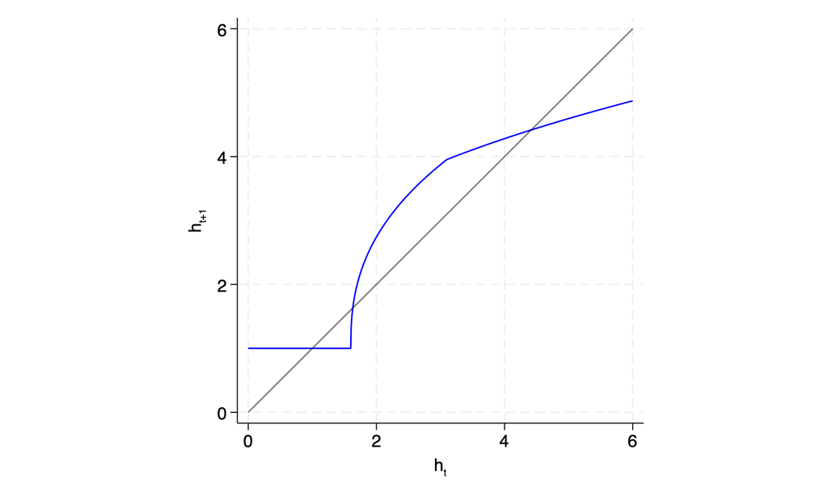

## Referene

- Becker, G. S. (1962) “Investment in human capital: A theoretical analysis,” *Journal of Political Economy*, 70.
- Glomm, G. and B. Ravikumar (1992) “Public versus private investment in human capital: Endogenous growth and income inequality,” *Journal of Political Economy*.
- Lucas, R. E. (1988) “On the mechanics of economic development,” *Journal of Monetary Economics*.
- Mankiw, N. G., D. Romer , D. N. Weil (1992) “A contribution to the empirics of economic growth,” *Quarterly Journal of Economics*, 107.
- Mincer, J. (1958) “Investment in human capital and personal income distribution,” *Journal of Political Economy*, 66.